# Cleaning slides

```python
import pandas as pd
import numpy as np
import matplotlib.pyplot as plt
import seaborn as sns
import scipy.stats as stats
```

```python
pd.set_option('display.max_columns', 12)
```

Data cleaning functions. Used the USAPL Rulebook from 2021. potential issue: data is from 2017.

```python
def assign_tier(age, division):
    if 'open' in division.lower() or '-o' in division.lower():
        return np.nan
    elif division.lower == 'teens':
        return '3'
    elif '1a' in division.lower():
        return '1a'
    elif '1b' in division.lower():
        return '1b'
    elif '2a' in division.lower():
        return '2a'
    elif '2b' in division.lower():
        return '2b'
    elif '3a' in division.lower():
        return '3a'
    elif '3b' in division.lower():
        return '3b'
    elif '4a' in division.lower():
        return '4a'
    elif '4b' in division.lower():
        return '4b'
    elif '5a' in division.lower():
        return '5a'
    elif '5b' in division.lower():
        return '5b'
    elif '6a' in division.lower():
        return '6a'
    elif '6b' in division.lower():
        return '6b'
    elif 'jr' in division.lower() or 'jnr' in division.lower() or 'junior' in division.lower():
        return np.nan
    elif age < 10:
        return str(1)
    elif age < 12:
        return str(2)
    elif '11' in division:
        return str(2)
    elif age < 14:
        return str(3)
    elif '13' in division:
        return str(3)
    elif age < 16:
        return str(1)
    elif '15' in division:
        return str(1)
    elif age < 18:
        return str(2)
    elif '17' in division:
        return str(2)
    elif age < 20:
        return str(3)
    elif '19' in division:
        return str(3)
    elif age < 25:
        return np.nan
    elif '24' in division:
        return np.nan
    elif age < 40:
        return np.nan
    elif age < 45:
        return '1a'
    elif '44' in division:
        return '1a'
    elif age < 50:
        return '1b'
    elif '49' in division or 'm1' in division.lower():
        return '1b'
    elif age < 55:
        return '2a'
    elif '54' in division:
        return '2a'
    elif age < 60:
        return '2b'
    elif '59' in division or 'm2' in division.lower():
        return '2b'
    elif age < 65:
        return '3a'
    elif '64' in division:
        return '3a'
    elif age < 70:
        return '3b'
    elif '69' in division or 'm3' in division.lower():
        return '3b'
    elif age < 75:
        return '4a'
    elif '74' in division:
        return '4a'
    elif age < 80:
        return '4b'
    elif '79' in division or 'm5' in division.lower():
        return '4b'
    elif age < 85:
        return '5a'
    elif '84' in division:
        return '5b'
    elif age < 90:
        return '6b'
    elif '89' in division or 'm6' in division.lower():
        return '6b'
    elif age >= 90:
        return '6b'
    else:
        return np.nan
```

```python
def assign_level(age, division):
    if 'open' in division.lower() or '-s' in division.lower():
        return 'Open'
    elif age < 14:
        return 'Youth'
    elif '14' in division:
        return 'Youth'
    elif age < 20:
        return 'Teen'
    elif '16' in division or 'teen' in division.lower():
        return 'Teen'
    elif '18' in division:
        return 'Teen'
    elif age < 25:
        return 'Juniors'
    elif 'jr' in division.lower() or 'jnr' in division.lower() or 'junior' in division.lower() or  '-j' in division.lower():
        return 'Juniors'
    elif age < 40:
        return 'Open'
    elif 'master' in division.lower():
        return 'Masters'
    elif age >= 40:
        return 'Masters'
    else:
        return np.nan
```

```python
def assign_level2(tier, level):
    if 'a' in tier or 'b' in tier:
        return 'Masters'
    else:
        np.nan
```

```python
def assign_open_level(division):
    if ('guest' in division.lower() or \
        'disabled' in division.lower() or \
        'novice' in division.lower() or \
        'special' in division.lower() or \
        'amateur' in division.lower() or \
        'handycap' in division.lower() or \
        'veteran' in division.lower() or \
        'wheel' in division.lower()):
        return 'Special'
    else:
        return np.nan
```

```python
lifts_raw = pd.read_csv('openpowerlifting.csv')
```

```python
print(lifts_raw.isnull().sum())
```

```
MeetID                 0
Name                   0
Sex                    0
Equipment              0
Age               239267
Division           15843
BodyweightKg        2402
WeightClassKg       3812
Squat4Kg          385171
BestSquatKg        88343
Bench4Kg          384452
BestBenchKg        30050
Deadlift4Kg       383614
BestDeadliftKg     68567
TotalKg            23177
Place               1092
Wilks              24220
dtype: int64
```

I should have checked the amount of null in age before i attempted to calculate division based on age. There are 15k plus null divisions.

```python
print(lifts_raw.nunique())
```

```
MeetID              8482
Name              136687
Sex                    2
Equipment              5
Age                  167
Division            4246
BodyweightKg        9110
WeightClassKg         51
Squat4Kg             438
BestSquatKg         1507
Bench4Kg             526
BestBenchKg         1470
Deadlift4Kg          573
BestDeadliftKg      1385
TotalKg             4340
Place                 81
Wilks              64827
dtype: int64
```

there are 4246 unique divisions

```python
lifts = lifts_raw.copy()
lifts['Division'] = lifts['Division'].fillna('').astype(str)
del lifts['Squat4Kg']
del lifts['Bench4Kg']
del lifts['Deadlift4Kg']
```

```python
lifts.loc[lifts['WeightClassKg'] == '90+', 'WeightClassKg'] = 90
```

```python
lifts['Level'] = lifts.apply(lambda row: assign_level(row['Age'], row['Division']), axis=1)
```

```python
lifts['Tier'] = lifts.apply(lambda row: assign_tier(row['Age'], row['Division']), axis=1)
```

```python
lifts['Tier'] = lifts['Tier'].fillna('').astype(str)
```

```python
lifts['Level2'] = lifts.apply(lambda row: assign_level2(row['Tier'], row['Level']), axis=1)
```

```python
lifts['OpenLevel'] = lifts['Division'].apply(assign_open_level)
```

```python
lifts['OpenLevel'] = lifts['OpenLevel'].fillna(lifts['Level'])
```

```python
lifts['OpenLevel'] = lifts['OpenLevel'].fillna(lifts['Level2'])
```

```python
lifts['Level'] = lifts['OpenLevel']
del lifts['OpenLevel']
```

```python
lifts['Division2'] = lifts['Division']
lifts['Division'] = lifts['Level'] + ' ' + lifts['Tier'].fillna(str(1))
```

```python
lifts.to_csv('lifts_data.csv', index=False)
```

```python
print(lifts.info())
```

[output not shown]

there are 386,414 total observations in the file. some of the bestlift columns are missing data.

```python
print(lifts.describe())
```

```
              MeetID            Age   BodyweightKg    BestSquatKg
count  386414.000000  147147.000000  384012.000000  298071.000000  \
mean     5143.015804      31.668237      86.934912     176.569941
std      2552.099838      12.900342      23.140843      69.222785
min         0.000000       5.000000      15.880000    -477.500000
25%      2979.000000      22.000000      70.300000     127.500000
50%      5960.000000      28.000000      83.200000     174.630000
75%      7175.000000      39.000000     100.000000     217.720000
max      8481.000000      95.000000     242.400000     573.790000

         BestBenchKg  BestDeadliftKg        TotalKg          Wilks
count  356364.000000   317847.000000  363237.000000  362194.000000
mean      118.347509      195.040633     424.000249     301.080601
std        54.848850       61.580675     196.355147     116.360396
min      -522.500000     -410.000000      11.000000      13.730000
25%        79.380000      147.500000     272.160000     237.380000
50%       115.000000      195.000000     424.110000     319.660000
75%       150.000000      238.140000     565.000000     379.290000
max       488.500000      460.400000    1365.310000     779.380000
```

There are negative values in some of the best lift columns

```python
print(lifts.isnull().sum())
```

[output not shown]

```python
print(lifts.nunique())
```

[output not shown]

```python
print(lifts.duplicated().sum())
```

```
545
```

At this point, i will call my initial iteration of the dataset clean. (note from future derick, you are not done)

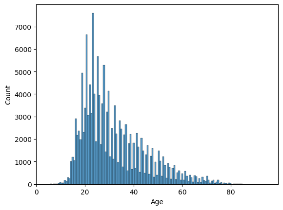

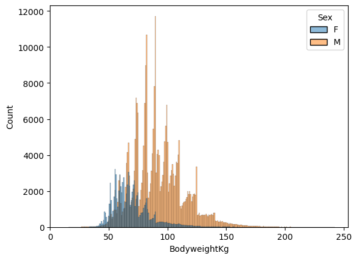

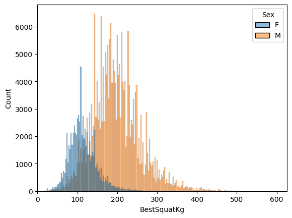

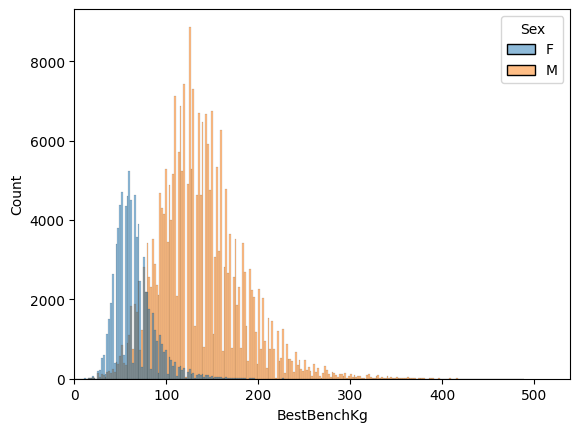

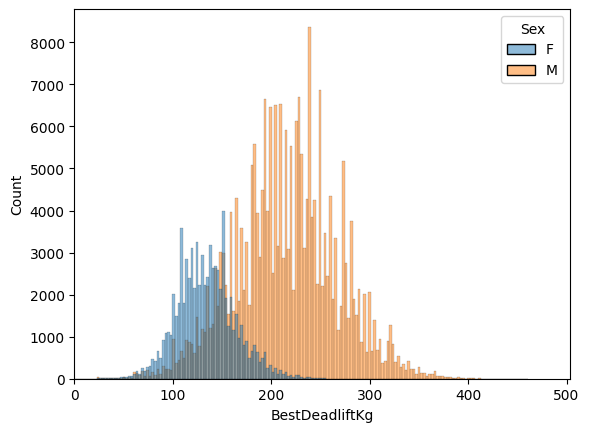

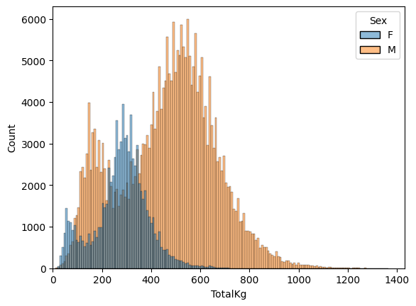

```python
sns.histplot(lifts['Age'])
plt.xlim(left=0)
plt.show()

sns.histplot(data=lifts, x='BodyweightKg', hue='Sex')
plt.xlim(left=0)
plt.show()

sns.histplot(data=lifts, x='BestSquatKg', hue='Sex')
plt.xlim(left=0)
plt.show()

sns.histplot(data=lifts, x='BestBenchKg', hue='Sex')
plt.xlim(left=0)
plt.show()

sns.histplot(data=lifts, x='BestDeadliftKg', hue='Sex')
plt.xlim(left=0)
plt.show()

sns.histplot(data=lifts, x='TotalKg', hue='Sex')
plt.xlim(left=0)
plt.show()
```

the totalkg hist shows bi-modality in both males and females. WHY???

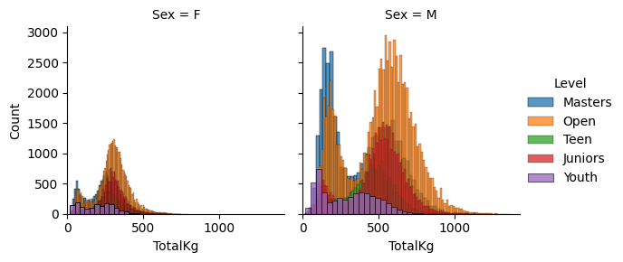

```python
# create two separate histograms for males and females
g = sns.FacetGrid(lifts, col='Sex', hue='Level')
g.map(sns.histplot, 'TotalKg')
g.set(xlim=(0, None))
g.add_legend()
```

Bimodality does not appear to be due to division.

```python
#test for lifting div differences
print(lifts.groupby('Division')['TotalKg'].describe())
print(lifts.groupby('Level')['TotalKg'].describe())
print(lifts.groupby('Level')['BestSquatKg'].describe())
```

[output not shown]

Rule out bimodality due to a certian division. I see we have some negative lifts. Lets drop our disqualified individuals from the dataframe.

```python
lifts = lifts[lifts['Place'] != 'DQ']
```

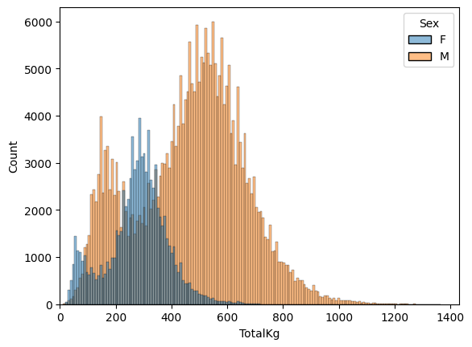

```python
sns.histplot(data=lifts, x='TotalKg', hue='Sex')
plt.xlim(left=0)
plt.show()
```

Still bi-modal.

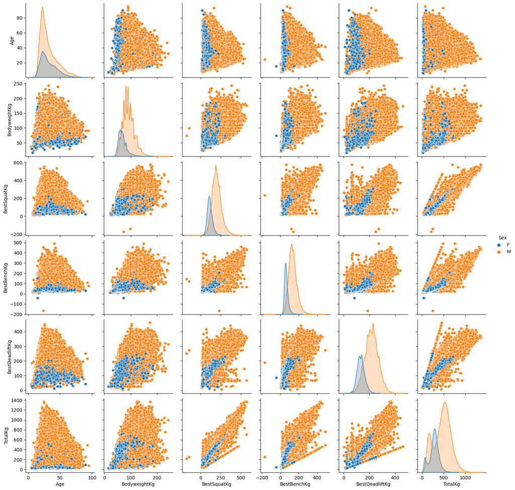

```python
sns.pairplot(lifts[['Age','BodyweightKg', 'BestSquatKg', 'BestBenchKg', 'BestDeadliftKg', 'TotalKg', 'Sex']], hue='Sex')
plt.show()
```

Still bimodal, but what is interesting is the negative value outliers still showing and the linear trend on the outsides of some scatter plots.

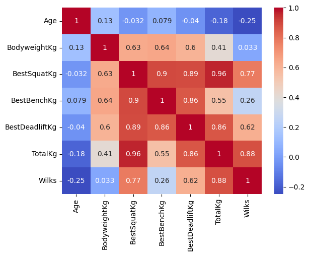

```python
corr_matrix = lifts[['Age', 'BodyweightKg', 'BestSquatKg', 'BestBenchKg', 'BestDeadliftKg', 'TotalKg', 'Wilks']].corr()
sns.heatmap(corr_matrix, annot=True, cmap='coolwarm')
plt.show()
```

Missing a lift impacts total, begin analysis of complete lifts.

```python
complete_lifts = lifts.copy()
complete_lifts[['BestBenchKg', 'BestSquatKg', 'BestDeadliftKg']] = complete_lifts[['BestBenchKg', 'BestSquatKg', 'BestDeadliftKg']].applymap(lambda x: np.nan if x < 0 else x)
complete_lifts = complete_lifts.dropna(subset=['BestSquatKg', 'BestBenchKg', 'BestDeadliftKg'])
```

```python
complete_lifts.to_csv('lifts_data.csv', index=False)
```

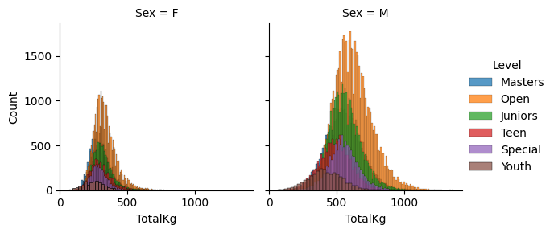

```python
# create two separate histograms for males and females
g = sns.FacetGrid(complete_lifts, col='Sex', hue='Level')
g.map(sns.histplot, 'TotalKg')
g.set(xlim=(0, None))
g.add_legend()
```

BINGO, The bimodality is gone. Lets find something to test.

```python
categorical_vars = ['Sex', 'Equipment', 'Division', 'WeightClassKg']
target_var1 = 'Place'
target_var2 = 'TotalKg'
```

```python
for var in categorical_vars:
    ct = pd.crosstab(lifts[var], lifts[target_var1])
    chi2, p, dof, expected = stats.chi2_contingency(ct)
    print(f"{var}: chi-square = {chi2:.2f}, p-value = {p:.4f}")
```

```
Sex: chi-square = 5402.42, p-value = 0.0000
Equipment: chi-square = 26046.06, p-value = 0.0000
Division: chi-square = 19653.05, p-value = 0.0000
WeightClassKg: chi-square = 20140.99, p-value = 0.0000
```

Equipment looks interesting.

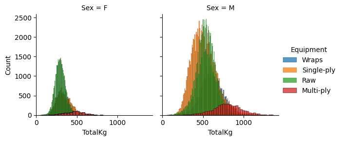

```python
# create two separate histograms for males and females
g = sns.FacetGrid(complete_lifts, col='Sex', hue='Equipment')
g.map(sns.histplot, 'TotalKg')
g.set(xlim=(0, None))
g.add_legend()
```

Single ply use in males seems to have a slightly lower distribution than raw. wondering if that is equipment that buffers an injury or something. multi ply seems to give an advantage in both males and females but is not widely used.

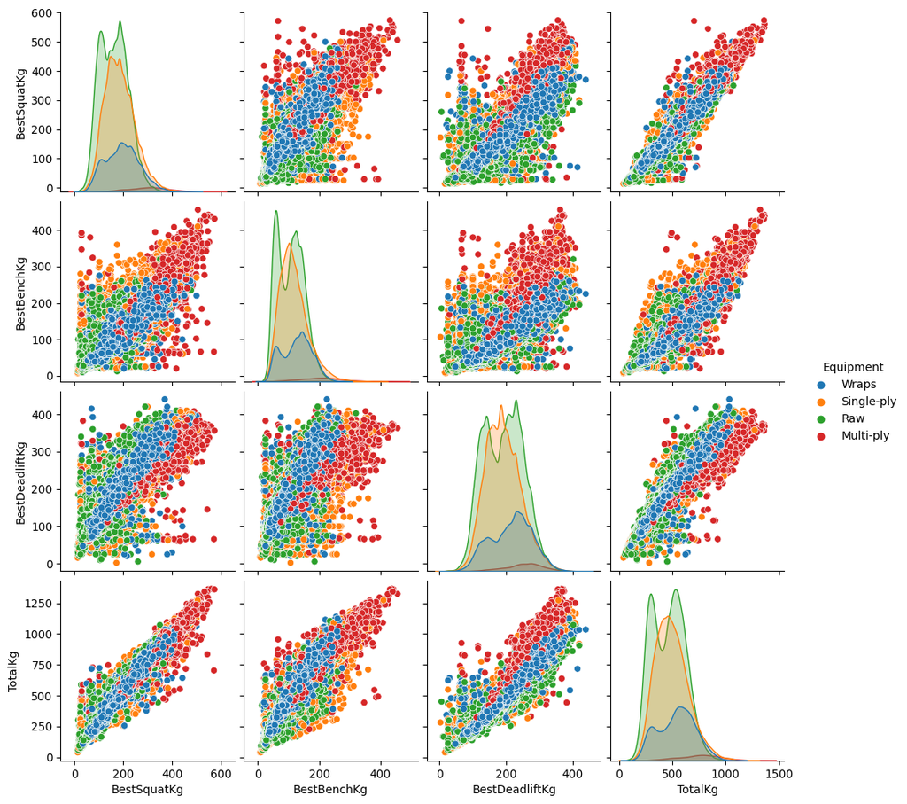

```python
sns.pairplot(complete_lifts[['BestSquatKg', 'BestBenchKg', 'BestDeadliftKg', 'TotalKg', 'Equipment']], hue='Equipment')
plt.show()
```

I am fairly certain that the bimodality above is due to male/female. curious why multiply has a smooth curve. be sure to control for sex when determining the impact

```python
print(complete_lifts.groupby(['Equipment', 'Sex'])['TotalKg'].describe())
print(complete_lifts.groupby(['Equipment', 'Sex'])['BestBenchKg'].describe())
print(complete_lifts.groupby(['Equipment', 'Sex'])['BestSquatKg'].describe())
print(complete_lifts.groupby(['Equipment', 'Sex'])['BestDeadliftKg'].describe())
```

```
                  count        mean         std     min      25%     50%
Equipment  Sex
Multi-ply  F      738.0  470.328442  121.675401  117.50  385.625  474.00  \
           M     4392.0  799.692065  176.502694  175.00  689.460  800.00
Raw        F    45108.0  298.957785   66.409433   54.00  255.000  295.00
           M    87371.0  540.646436  118.774678   55.00  465.000  540.00
Single-ply F    12839.0  345.977904   96.172494   40.80  279.500  335.00
           M    91812.0  511.824007  150.441084   38.60  403.700  498.95
Wraps      F    10875.0  324.197191   81.102760   86.18  267.500  315.00
           M    33053.0  606.587188  135.159766   70.00  517.500  602.50

                   75%      max
Equipment  Sex
Multi-ply  F    552.50   816.47
           M    913.99  1365.31
Raw        F    340.00   730.28
           M    615.00  1105.00
Single-ply F    402.50   763.00
           M    602.50  1272.50
Wraps      F    372.50   772.50
           M    694.00  1140.00
                  count        mean        std    min     25%     50%     75%
Equipment  Sex
Multi-ply  F      738.0  112.077737  39.973418  22.68   83.91  110.34  140.61  \
           M     4392.0  217.241737  66.404040  20.00  174.63  215.46  260.00
Raw        F    45139.0   60.793871  15.813315  10.00   50.00   60.00   70.00
           M    87415.0  129.251811  32.970200  12.47  107.50  127.50  150.00
Single-ply F    12842.0   74.713013  28.796035   9.10   55.00   70.00   90.00
           M    91832.0  122.404350  45.370013   6.80   90.72  115.00  145.15
Wraps      F    10875.0   65.794204  19.594535   9.07   52.50   62.50   77.11
           M    33053.0  146.162340  37.038854  17.50  120.20  145.00  170.01

                   max
Equipment  Sex
Multi-ply  F    242.67
           M    455.86
Raw        F    188.24
           M    320.00
Single-ply F    227.00
           M    410.00
```

[output cut: 29 more lines]

```
Single-ply F    12842.0  139.310818  31.720492  18.10  117.50  137.50  160.00
           M    91832.0  197.523213  51.307128   2.27  160.00  192.78  230.00
Wraps      F    10875.0  139.191596  31.208452  20.41  117.50  137.50  158.76
           M    33053.0  239.423210  48.269208  25.00  208.65  240.00  272.50

                   max
Equipment  Sex
Multi-ply  F    250.00
           M    410.50
Raw        F    273.00
           M    420.50
Single-ply F    270.50
           M    420.00
Wraps      F    272.16
           M    440.00
```

```python
print(complete_lifts.groupby(['Level', 'Sex'])['TotalKg'].describe())
print(complete_lifts.groupby(['Level', 'Sex'])['BestBenchKg'].describe())
print(complete_lifts.groupby(['Level', 'Sex'])['BestSquatKg'].describe())
print(complete_lifts.groupby(['Level', 'Sex'])['BestDeadliftKg'].describe())
```

```
               count        mean         std    min     25%     50%     75%
Level   Sex
Juniors F    10969.0  313.250499   72.839285  88.45  265.00  305.00  350.50  \
        M    31786.0  558.464703  123.348621  60.00  480.00  552.50  632.50
Masters F    11243.0  299.426949   79.209545  90.00  245.00  290.00  342.50
        M    24160.0  556.162607  134.542271  75.00  465.00  555.00  642.50
Open    F    25324.0  332.222748   82.501804  72.60  275.00  320.00  376.48
        M    56650.0  622.539546  142.765480  75.00  525.00  610.00  707.50
Special F     4183.0  288.656266   61.250284  70.31  249.48  283.50  324.32
        M    10985.0  553.334270  113.098096  69.99  483.08  548.85  623.69
Teen    F     4851.0  300.056395   77.841612  40.80  247.50  290.00  346.25
        M    11659.0  490.995036  120.386175  38.60  410.50  490.00  567.50
Youth   F      920.0  252.551174   81.187492  54.00  195.00  253.75  300.00
        M     2918.0  414.746792  126.459473  38.60  330.00  410.00  502.50

                 max
Level   Sex
Juniors F     730.28
        M    1230.00
Masters F     747.50
        M    1155.00
Open    F     796.05
        M    1365.31
Special F     641.83
        M    1054.60
Teen    F     640.00
        M    1055.00
Youth   F     660.00
        M     901.00
               count        mean        std    min     25%     50%     75%
Level   Sex
Juniors F    10972.0   63.674996  19.494008  18.14   50.00   60.00   72.50  \
        M    31797.0  132.755982  35.827671  20.00  110.00  130.00  152.50
Masters F    11250.0   63.729976  21.151807  20.00   50.00   60.00   72.50
        M    24169.0  140.541035  41.418100  20.00  112.50  137.50  165.00
Open    F    25330.0   69.178420  22.575934  17.50   55.00   65.00   79.38
        M    56683.0  153.618672  44.003963  12.50  124.74  147.50  177.50
Special F     4183.0   58.426868  14.609155  15.00   47.63   56.70   65.77
        M    10985.0  133.947804  33.872732  15.00  112.50  131.54  151.95
Teen    F     4852.0   59.889889  19.960936   9.07   45.40   55.00   70.00
```

[output cut: 61 more lines]

```

                max
Level   Sex
Juniors F    265.00
        M    420.50
Masters F    248.00
        M    400.00
Open    F    273.00
        M    440.00
Special F    231.33
        M    376.48
Teen    F    247.50
        M    355.50
Youth   F    250.00
        M    317.50
```

```python
eda_subset = complete_lifts[complete_lifts['Sex'].str.lower() == 'm']
```

```python
print(complete_lifts.groupby(['Equipment','Level'])['TotalKg'].describe())
print(complete_lifts.groupby(['Equipment','Level'])['BestBenchKg'].describe())
print(complete_lifts.groupby(['Equipment','Level'])['BestSquatKg'].describe())
print(complete_lifts.groupby(['Equipment','Level'])['BestDeadliftKg'].describe())
```

```
                      count        mean         std     min       25%     50%
Equipment  Level
Multi-ply  Juniors    287.0  722.358780  185.201870  175.00  623.6900  739.35  \
           Masters   1076.0  678.364312  181.207295  117.50  546.5800  700.90
           Open      2519.0  793.319444  202.152660  155.36  668.2750  814.20
           Special    640.0  676.184703  157.545290  222.26  576.0600  706.47
           Teen       155.0  580.351226  172.309464  185.00  473.7500  605.00
           Youth        1.0  405.000000         NaN  405.00  405.0000  405.00
Raw        Juniors  27782.0  475.321198  142.756709   60.00  352.5000  490.00
           Masters  17905.0  420.011798  151.752734   75.00  290.0000  410.00
           Open     45652.0  481.414346  162.028170   72.60  335.0000  490.00
           Special   5862.0  429.783257  143.969115   69.99  294.8775  445.00
           Teen     10075.0  423.524781  132.349766  102.06  315.0000  427.50
           Youth     1295.0  300.499575  123.324543   54.00  205.0000  282.50
Single-ply Juniors   9442.0  516.666929  171.031815   79.40  387.8200  512.50
           Masters  10411.0  531.720435  158.958724   75.00  410.0000  545.00
           Open     15376.0  588.284555  185.110823   97.07  452.5000  592.50
           Special    437.0  516.366682  148.635037  185.97  412.7700  517.10
           Teen      3720.0  446.498793  148.236722   38.60  327.5000  428.32
           Youth     2452.0  418.450701  123.925604   38.60  325.0000  411.25
Wraps      Juniors   5244.0  552.315814  159.131564   88.45  447.5000  567.50
           Masters   6011.0  501.975227  166.406141  132.50  362.8700  512.50
           Open     18427.0  578.429014  179.936140  119.06  442.2500  598.74
           Special   8229.0  499.213297  147.251966   90.72  383.2900  525.00
           Teen      2560.0  453.961941  145.893704   86.18  340.0000  464.93
           Youth       90.0  299.835000  128.176371  104.33  209.3750  285.38

                         75%      max
Equipment  Level
Multi-ply  Juniors  857.3900  1224.70
           Masters  809.7450  1155.00
           Open     934.4000  1365.31
           Special  787.5475  1054.60
           Teen     697.9000   952.54
           Youth    405.0000   405.00
Raw        Juniors  580.0000   985.00
           Masters  540.0000  1010.00
           Open     600.0000  1105.00
           Special  544.3100   875.43
           Teen     520.0000   880.50
```

[output cut: 157 more lines]

```
           Special  226.8000  324.32
           Teen     215.0000  355.50
           Youth    160.0000  300.00
Single-ply Juniors  240.0000  390.00
           Masters  244.9400  400.00
           Open     265.0000  420.00
           Special  233.6000  326.59
           Teen     215.0000  340.00
           Youth    200.0000  317.50
Wraps      Juniors  262.5000  402.50
           Masters  245.0000  387.82
           Open     275.0000  440.00
           Special  242.6700  367.41
           Teen     227.5000  345.00
           Youth    149.9225  250.00
```

```python
equipment_dummies = pd.get_dummies(complete_lifts['Equipment'], prefix='Eq')
level_dummies = pd.get_dummies(complete_lifts['Level'], prefix='Lvl')
complete_lifts_rg = pd.concat([complete_lifts, equipment_dummies, level_dummies], axis=1)
```

```python
cols = ['WeightClassKg', 'TotalKg', 'BestBenchKg', 'BestSquatKg', 'BestDeadliftKg']
data = complete_lifts[cols]
corr_matrix = data.corr()
sns.heatmap(corr_matrix, cmap='coolwarm', annot=True)
plt.title('Correlation Matrix')
plt.show()
```

[output not shown]